# Factores Socioeconómicos y Energéticos Asociados a la Generación de Electricidad: Un Análisis de Regresión Lineal Múltiple con Datos de Our World in Data para 2022

Santiago Mendoza Buitrago (2515503), Daniela Mosquera Ceballos (2520865), Jose Manuel Toro Rodriguez (2421804), Neyer Andrés Angulo Hurtado (2372140); 5 de Octubre de 2026

# 1 Introducción

La energía es un recurso fundamental para el desarrollo y funcionamiento de los países, ya que está presente en las actividades económicas, industriales y sociales que se realizan diariamente. Sin embargo, la cantidad de energía que genera cada país no es la misma y puede estar relacionada con diferentes características de su población y de su economía. Factores como el número de habitantes, el Producto Interno Bruto (PIB), el porcentaje de población que vive en zonas urbanas y el acceso a la electricidad pueden tener relación con la cantidad de energía generada.

Para responder esta pregunta, se analizarán los datos correspondientes a diferentes países durante el año 2022, tomando como variable principal la generación total de energía y relacionándola con variables demográficas, económicas y sociales. De esta manera, se busca conocer si las diferencias en estas características están relacionadas con las diferencias en la cantidad de energía generada por cada país.

Así, el estudio permitirá tener una visión más clara de cómo las características de los países pueden estar relacionadas con su capacidad de generación de energía y de qué manera los aspectos económicos, demográficos y sociales se relacionan entre sí.

# 2 Fuente y construcción de la base.

Para el desarrollo del estudio se construyó una base de datos a partir de información pública proveniente de Our World in Data (OWID) y el Banco Mundial, seleccionando los registros correspondientes al año 2022. La unidad de análisis es el país, por lo que cada fila de la base representa un país con información disponible para las variables consideradas en el estudio.

La generación total de electricidad, medida en teravatios-hora (TWh), se obtuvo de Electricity Mix de Our World in Data. La población total se obtuvo del Population & Demography Data Explorer de la misma plataforma, mientras que la clasificación por continente se tomó de World regions according to Our World in Data. Esta última fuente corresponde a las regiones definidas por OWID y utilizadas en sus gráficos y mapas.

Por otra parte, el PIB total, expresado en dólares estadounidenses a precios actuales, y el consumo de energía eléctrica per cápita, expresado en kWh por habitante, fueron obtenidos del Banco Mundial. Finalmente, el acceso a electricidad, medido como el porcentaje de la población con acceso al servicio eléctrico, se obtuvo de la sección Access to Energy de Our World in Data.

Debido a que las variables se encontraban distribuidas en diferentes conjuntos de datos, fue necesario realizar un proceso de integración. Para ello, las bases fueron organizadas utilizando el código de país como identificador común, lo que permitió relacionar correctamente la información de generación, población, PIB, consumo de electricidad per cápita, acceso a electricidad y continente para cada país.

Posteriormente, se realizó la depuración de los datos. Se revisaron posibles registros duplicados, valores faltantes y la correcta codificación de las variables. En el caso del consumo de electricidad per cápita se identificaron 49 observaciones sin información disponible, las cuales fueron reconocidas como valores faltantes. Para garantizar que todas las observaciones utilizadas en el análisis contaran con información completa en las variables seleccionadas, se trabajó únicamente con casos completos.

Después del proceso de integración, revisión y depuración, la base final quedó conformada por 140 países, con información completa para las variables incluidas en el estudio. Esta base fue utilizada posteriormente para realizar el análisis descriptivo y estimar el modelo de regresión lineal múltiple.

# 3 Metodología

El estudio se desarrolló mediante un enfoque cuantitativo de corte transversal, utilizando información correspondiente a 140 países durante el año 2022. Para analizar la relación entre la generación total de electricidad y diferentes características socioeconómicas y energéticas, se empleó un modelo de regresión lineal múltiple estimado mediante Mínimos Cuadrados Ordinarios (MCO). La variable dependiente fue la generación total de electricidad, expresada en teravatios-hora (TWh), mientras que como variables explicativas se incluyeron la población total, el PIB total, el consumo de electricidad per cápita, el acceso a electricidad y el continente. Estas variables fueron seleccionadas por su relación conceptual con el fenómeno estudiado: la población representa la dimensión demográfica de cada país, el PIB refleja el tamaño de su economía, el consumo per cápita representa la intensidad del uso de electricidad, el acceso a electricidad refleja la cobertura del servicio y el continente permite considerar diferencias geográficas entre los países.

El modelo planteado se expresa como:

$$Gen Elect = \beta_0 + \beta_1(Pob) +
\beta_2(PIB) + \beta_3(Cons EelectPerCapital) + \beta_4(Continente) +
\beta_5(Acceso Elect) + \epsilon$$

Los coeficientes fueron estimados mediante MCO, método que busca minimizar la suma de los cuadrados de las diferencias entre los valores observados y los estimados por el modelo. Cada coeficiente cuantitativo representa el cambio esperado en la generación total de electricidad asociado con un aumento de una unidad en la variable correspondiente, manteniendo constantes las demás variables. Para evaluar los resultados se analizaron los coeficientes estimados, errores estándar, estadísticos t y valores p, además del R² ajustado y la prueba F para evaluar el comportamiento global del modelo. Finalmente, se realizaron diagnósticos de linealidad, normalidad de los residuos, homocedasticidad y multicolinealidad mediante VIF/GVIF, con el propósito de verificar el cumplimiento de los principales supuestos de la regresión lineal y considerar sus posibles limitaciones al momento de interpretar los resultados.

## 3.1 Descricpión del modelo

El modelo será estimado mediante Mínimos Cuadrados Ordinarios (MCO), utilizando una muestra de 140 países con información correspondiente al año 2022, obtenida de Our World in Data. La generación total de electricidad será la variable dependiente y se analizará su relación con factores socioeconómicos y energéticos como la población, el PIB, el consumo de electricidad per cápita, el acceso a electricidad y el continente.

Tabla de Variables del Modelo de Regresión

| Variable | Descripción | Tipo de variable | Unidad / Notas |
| --- | --- | --- | --- |
| Generacion | Generación total de electricidad del país | Dependiente - cuantitativa continua | TWh |
| β₀ | Intercepto del modelo | Parámetro | Intercepto |
| Poblacion | Población total del país | Cuantitativa | Habitantes |
| PIB | Producto Interno Bruto total del país | Cuantitativa continua | USD |
| Consumo | Consumo de electricidad per cápita | Cuantitativa continua | kWh per cápita |
| Acceso | Población con acceso a electricidad | Cuantitativa continua | % |
| Continente | Continente al que pertenece el país | Categórica nominal | Categoría de referencia |
| ε | Término de error aleatorio | Error | Factores no observados |

## 3.2 Base de datos del estudio

Para este estudio se utiliza una base de datos construida a partir de información de Our World in Data para el año 2022. La base final está conformada por 140 países y reúne las variables seleccionadas para el modelo: generación total de electricidad, población, PIB total, consumo de electricidad per cápita, acceso a electricidad y continente. La información fue integrada mediante el código de cada país y posteriormente depurada para trabajar únicamente con observaciones completas y consistentes.

Base de Datos – Indicadores Energéticos 2022

140 países | Fuente: Our World in Data y Banco Mundial

| Código | Generación (TWh) | Población | Continente | Consumo (kWh per cápita) | PIB total (USD) | Acceso a electricidad |
| --- | --- | --- | --- | --- | --- | --- |
| ALB | 6.97 | 2827614 | Europe | 2840.960077 | 47534262248 | 100 |
| DZA | 91.47 | 45477391 | Africa | 1756.587213 | 672255873183 | 100 |
| AGO | 17.31 | 35635028 | Africa | 373.0318278 | 311841911795 | 48.5 |
| ARG | 145.61 | 45407904 | South America | 2833.119098 | 1263476170672 | 100 |
| ARM | 9.88 | 2880880 | Asia | 2403.677758 | 53107640868 | 100 |
| AUS | 272.92 | 26200987 | Oceania | 9923.431671 | 1561881261293 | 100 |
| AUT | 64.47 | 9064678 | Europe | 8254.393929 | 593999511161 | 100 |
| AZE | 28.94 | 10295307 | Asia | 2365.86248 | 213496582468 | 100 |
| BHR | 35.68 | 1533460 | Asia | 23151.54592 | 87781147010 | 100 |
| BGD | 102.25 | 169384891 | Asia | 603.6429564 | 1336135828193 | 99.4 |

[output cut: 130 more lines]

Elaboración propia con base en Our World in Data (2022) y el Banco Mundial.

# 4 4 Resultados descriptivos

## 4.1 Análisis Univariado de las variables del Modelo

### 4.1.1 Generación de electricidad

En la Tabla 1 se presentan las estadísticas descriptivas de la generación de electricidad de los países incluidos en el estudio, agrupadas por continente. Los resultados muestran diferencias importantes tanto en el nivel promedio de generación como en su dispersión, lo que permite observar que la producción de electricidad no se distribuye de manera uniforme entre los países analizados.

Tabla 1: Estadísticas descriptivas de la generación de electricidad por continente

| Continente | N | Generación promedio (TWh) | Desv. Estándar | Mínimo | Máximo |
| --- | --- | --- | --- | --- | --- |
| Africa | 35 | 25.81 | 53.47 | 0.39 | 239.17 |
| Asia | 41 | 388.42 | 1393.20 | 4.37 | 8848.71 |
| Europe | 39 | 120.45 | 215.22 | 1.21 | 1166.94 |
| North America | 13 | 414.52 | 1179.75 | 1.01 | 4286.89 |
| Oceania | 2 | 158.08 | 162.40 | 43.25 | 272.92 |
| South America | 10 | 116.24 | 201.87 | 2.11 | 677.16 |

Los resultados muestran diferencias importantes en la generación de electricidad entre los países analizados. North America presenta el promedio más alto con 414,52 TWh, seguido de Asia con 388,42 TWh, mientras que África registra el promedio más bajo con 25,81 TWh. Además, se observa una alta dispersión entre países, especialmente en Asia y North America, donde algunos presentan niveles de generación considerablemente superiores al resto. Esto muestra que, incluso dentro de un mismo continente, la generación de electricidad puede variar ampliamente. En el caso de Oceania, los resultados deben interpretarse con cautela debido a que solo se incluyen dos países.

El mapa permite observar la distribución geográfica de la generación de electricidad en 2022, evidenciando una marcada heterogeneidad entre países. Se destacan algunos países con niveles de generación considerablemente superiores al resto, mientras que gran parte presenta valores más bajos. Esta distribución refleja que las diferencias en generación no solo se presentan entre continentes, sino también entre países de una misma región.

❖ Distribución Geoespacial de la Generación de Electricidad 2022 ❖

Teravatios-hora (TWh) por país | Fuente: Our World in Data, 2022

[interactive chart not shown]

## 4.2 Variables Explicativas Cuantitativas

### 4.2.1 Consumo de energía per capitá

El consumo de electricidad per cápita representa la cantidad de electricidad consumida por habitante, expresada en kWh per cápita. En la tabla se presentan sus principales estadísticas descriptivas para los 140 países de la muestra, agrupados según el continente al que pertenecen.

Tabla 2: Estadísticas descriptivas del consumo de electricidad per cápita por continente

| Continente | N | Consumo promedio | Desv. Estándar | Mínimo | Máximo |
| --- | --- | --- | --- | --- | --- |
| Africa | 35 | 767.41 | 941.45 | 15.55 | 3979.07 |
| Asia | 41 | 5099.65 | 5596.50 | 321.38 | 23151.55 |
| Europe | 39 | 6154.70 | 3825.14 | 2255.35 | 23373.47 |
| North America | 13 | 3682.75 | 4847.97 | 76.24 | 14901.64 |
| Oceania | 2 | 9034.07 | 1257.74 | 8144.72 | 9923.43 |
| South America | 10 | 2433.11 | 1084.83 | 859.64 | 4405.86 |

En la tabla se observan diferencias importantes en el consumo de electricidad per cápita entre los continentes. Oceania presenta el promedio más alto, con 9.034,07 kWh per cápita, aunque este resultado debe interpretarse con cautela porque solo incluye dos países. Le siguen Europe con 6.154,70 kWh y Asia con 5.099,65 kWh, mientras que Africa registra el promedio más bajo, con 767,41 kWh per cápita. También se evidencia una alta dispersión dentro de algunos continentes, especialmente en Asia y North America, lo que muestra que existen diferencias considerables entre los países de una misma región. Por su parte, el diagrama de dispersión muestra una tendencia positiva entre el consumo per cápita y la generación total de electricidad, aunque los puntos se encuentran bastante dispersos y existen algunos valores extremos. Por esta razón, la relación deberá evaluarse posteriormente junto con las demás variables del modelo de regresión.

Para facilitar la visualización de esta relación, se presentan dos versiones del diagrama de dispersión: una con los 140 países de la muestra y otra excluyendo únicamente de la visualización los 20 países con mayor generación de electricidad. Esta segunda gráfica permite observar con mayor claridad la distribución y la tendencia del resto de los países, evitando que los valores extremos compriman visualmente la mayoría de las observaciones. Esta exclusión se realizó solo con fines gráficos y descriptivos, por lo que los países continúan incluidos en la base y en el modelo de regresión.

[interactive chart not shown]

### 4.2.2 Población total

La población total corresponde al número de habitantes de cada país incluido en el estudio. En la Tabla 3 se presentan sus principales estadísticas descriptivas para los 140 países de la muestra, agrupados por continente.

Tabla 3: Estadísticas descriptivas de la población por continente

| Continente | N | Población promedio | Desv. Estándar | Mínimo | Máximo |
| --- | --- | --- | --- | --- | --- |
| Africa | 35 | 37353338 | 44796150 | 1218921 | 223150906 |
| Asia | 41 | 112416953 | 307587964 | 455374 | 1425423209 |
| Europe | 39 | 19119542 | 29895328 | 528194 | 145579889 |
| North America | 13 | 45141777 | 95319428 | 1495923 | 341534041 |
| Oceania | 2 | 15666359 | 14898214 | 5131731 | 26200987 |
| South America | 10 | 40115633 | 62270828 | 623172 | 210306411 |

En la tabla 3 se puede ver como la población total también presenta diferencias amplias entre los países analizados. Asia registra el promedio más alto, con aproximadamente 112,4 millones de habitantes, seguida de North America y South America, mientras que Oceania presenta el promedio más bajo. La variabilidad es especialmente marcada en Asia, donde conviven países con poblaciones relativamente pequeñas y otros que superan los mil millones de habitantes. En el diagrama de dispersión se aprecia que, en general, los países con mayor población tienden a presentar una mayor generación de electricidad, aunque los puntos no siguen un comportamiento uniforme y algunos países se encuentran bastante alejados del grupo principal. Esto refleja que países con tamaños poblacionales similares pueden tener niveles de generación diferentes.

[interactive chart not shown]

### 4.2.3 PIB total

El PIB total representa el valor de la producción económica de cada país, expresado en dólares estadounidenses (USD). En la Tabla 4 se presentan sus principales estadísticas descriptivas para los 140 países de la muestra, agrupados por continente.

Tabla 4: Estadísticas descriptivas del PIB total por continente

| Continente | N | PIB promedio | Desv. Estándar | Mínimo | Máximo |
| --- | --- | --- | --- | --- | --- |
| Africa | 35 | 2.466715e+11 | 4.250435e+11 | 12100927320 | 1.842479e+12 |
| Asia | 41 | 1.838284e+12 | 5.020658e+12 | 34771064644 | 3.036079e+13 |
| Europe | 39 | 9.160439e+11 | 1.422724e+12 | 15953525339 | 5.606621e+12 |
| North America | 13 | 2.338753e+12 | 6.667834e+12 | 31504952370 | 2.432453e+13 |
| Oceania | 2 | 9.075842e+11 | 9.253158e+11 | 253287094503 | 1.561881e+12 |
| South America | 10 | 7.830390e+11 | 1.169676e+12 | 11679705719 | 3.902035e+12 |

El PIB total muestra una marcada diferencia en el tamaño de las economías incluidas en el estudio. North America presenta el promedio más alto, con aproximadamente 2,34 billones de USD, seguido de Asia con 1,84 billones de USD, mientras que África registra el menor promedio, cercano a 246,7 mil millones de USD. A su vez, existe una amplia dispersión entre los países, principalmente en North America y Asia, donde algunos valores son considerablemente superiores al resto. En el diagrama de dispersión se observa que los mayores niveles de PIB tienden a acompañarse de una mayor generación de electricidad, aunque gran parte de los países se concentra en valores más bajos y unas pocas observaciones se encuentran bastante alejadas del conjunto principal.

[interactive chart not shown]

### 4.2.4 Acceso a electricidad

El acceso a electricidad corresponde al porcentaje de la población de cada país que cuenta con acceso a este servicio. En la Tabla 5 se presentan sus principales estadísticas descriptivas para los 140 países incluidos en la muestra, agrupados por continente.

Tabla 5: Estadísticas descriptivas del acceso a electricidad por continente

| Continente | N | Acceso promedio (%) | Desv. Estándar | Mínimo | Máximo |
| --- | --- | --- | --- | --- | --- |
| Africa | 35 | 62.18 | 24.92 | 11.7 | 100 |
| Asia | 41 | 98.40 | 4.73 | 73.7 | 100 |
| Europe | 39 | 100.00 | 0.00 | 100.0 | 100 |
| North America | 13 | 94.03 | 13.99 | 49.3 | 100 |
| Oceania | 2 | 100.00 | 0.00 | 100.0 | 100 |
| South America | 10 | 99.51 | 1.20 | 96.2 | 100 |

Los resultados muestran que el acceso a electricidad es elevado en gran parte de los países analizados. Europe y Oceania presentan un promedio del 100 %, seguidos de South America con 99,51 % y Asia con 98,40 %. En contraste, Africa registra el promedio más bajo con 62,18 % y también la mayor dispersión, con una desviación estándar de 24,92, lo que refleja diferencias importantes entre los países de este continente. North America también presenta cierta variabilidad, con valores que van desde 49,3 % hasta 100 %. En el diagrama de dispersión se observa que muchos países se concentran cerca del 100 % de acceso, pero presentan niveles de generación de electricidad muy diferentes entre sí. Por esta razón, un acceso similar a la electricidad no necesariamente se relaciona con niveles similares de generación.

[interactive chart not shown]

## 4.3 Variable categórica: Distribución de Frecuencias

### 4.3.1 Continente

La variable continente permite clasificar los países de la muestra según su ubicación geográfica. En la Tabla 6 se presenta la distribución de frecuencias y porcentajes de los 140 países incluidos en el estudio.

Tabla 6: Distribución de frecuencias de los países según continente

| Continente | Frecuencia | Porcentaje (%) | Porcentaje Acumulado (%) |
| --- | --- | --- | --- |
| Asia | 41 | 29.3 | 29.3 |
| Europe | 39 | 27.9 | 57.1 |
| Africa | 35 | 25.0 | 82.1 |
| North America | 13 | 9.3 | 91.4 |
| South America | 10 | 7.1 | 98.6 |
| Oceania | 2 | 1.4 | 100.0 |

La muestra está conformada principalmente por países de Asia, con 41 observaciones (29,3 %), seguida de Europe con 39 (27,9 %) y Africa con 35 (25,0 %). En menor proporción se encuentran North America con 13 países (9,3 %), South America con 10 (7,1 %) y Oceania con solo 2 (1,4 %). Al observar la distribución de la generación de electricidad por continente, se evidencian diferencias importantes entre los países de cada grupo, con una mayor dispersión y presencia de valores elevados especialmente en Asia y North America. También se observa que el número de países no es igual entre continentes, por lo que los resultados de grupos con pocas observaciones, particularmente Oceania, deben interpretarse con cautela.

[interactive chart not shown]

# 5 Estimación del modelo de regresión multiple

Tabla 7: Resultados del modelo de regresión lineal múltiple

| Variable | Coeficiente | Error Estándar | Estadístico t | Valor p | Sig. |
| --- | --- | --- | --- | --- | --- |
| (Intercept) | 1.79718 | 105.22413 | 0.01708 | 0.9864 |  |
| Poblacion | 0 | 0 | 1.16954 | 0.2443 |  |
| PIB | 0 | 0 | 21.16211 | < 0.0001 | *** |
| Consumo | 0.00277 | 0.00554 | 0.49987 | 0.6180 |  |
| Acceso | -0.68043 | 1.56169 | -0.4357 | 0.6638 |  |
| ContinenteAsia | 1.96096 | 80.95144 | 0.02422 | 0.9807 |  |
| ContinenteEurope | -39.26934 | 83.50788 | -0.47025 | 0.6390 |  |
| ContinenteNorth America | -65.99239 | 93.84946 | -0.70317 | 0.4832 |  |
| ContinenteOceania | -6.87202 | 188.20229 | -0.03651 | 0.9709 |  |
| ContinenteSouth America | -9.03019 | 103.91658 | -0.0869 | 0.9309 |  |
| R² ajustado | 0.9192 |  |  |  |  |
| F | 176.75 |  |  |  |  |
| Valor p (modelo) | < 0.0001 |  |  |  |  |
| N | 140 |  |  |  |  |

Nota: Elaboración propia con base en Our World in Data, 2022.

El intercepto del modelo es 1,797 TWh y presenta un valor p de 0,9864, por lo que no es estadísticamente significativo. Este valor representa la generación esperada cuando las variables cuantitativas toman el valor de cero y el país pertenece al continente de referencia. Sin embargo, estas condiciones no representan un escenario realista para los países analizados, por lo que el intercepto tiene principalmente una función matemática dentro del modelo.

En cuanto a la población, el coeficiente aparece como cero debido a la escala en la que está medida la variable, ya que se encuentra expresada en número de habitantes. Su valor p es 0,2443, por lo que no presenta una asociación estadísticamente significativa con la generación de electricidad una vez se mantienen constantes las demás variables del modelo. Esto no significa que la población no tenga relación con la generación, sino que su efecto individual no resulta significativo al analizarla conjuntamente con los demás factores.

El PIB total es la única variable cuantitativa que presenta una asociación estadísticamente significativa con la generación de electricidad (p < 0,0001). Aunque su coeficiente aparece como cero en la tabla debido a que el PIB está expresado en dólares y, por tanto, el efecto de un solo dólar es muy pequeño, el estadístico t de 21,16 muestra una relación positiva y claramente significativa. En otras palabras, manteniendo constantes las demás variables, los países con un PIB total mayor tienden a presentar una mayor generación de electricidad.

Para el consumo de electricidad per cápita, el coeficiente estimado es 0,00277, lo que indica una asociación positiva con la generación. Sin embargo, esta relación no es estadísticamente significativa (p = 0,6180) después de controlar por las demás variables. De forma similar, el acceso a electricidad presenta un coeficiente de −0,68043 y un valor p de 0,6638, por lo que tampoco se encuentra evidencia suficiente de una asociación estadísticamente significativa dentro del modelo.

Para la variable continente, Africa funciona como categoría de referencia. Frente a ella, Asia presenta una diferencia estimada de 1,96 TWh, Europe de −39,27 TWh, North America de −65,99 TWh, Oceania de −6,87 TWh y South America de −9,03 TWh, manteniendo constantes las demás variables. Sin embargo, ninguna de estas diferencias es estadísticamente significativa, ya que todos sus valores p son superiores a 0,05. Por lo tanto, con esta muestra y una vez considerados simultáneamente los demás factores, no se encuentra evidencia suficiente para afirmar que la generación difiera por continente respecto a Africa.

Finalmente, el modelo presenta un R² ajustado de 0,9192, lo que indica que aproximadamente el 91,92 % de la variabilidad observada en la generación de electricidad entre los países de la muestra es explicada conjuntamente por las variables incluidas. Además, el estadístico F es 176,75 y el valor p global es menor a 0,0001, lo que indica que el modelo, considerado en conjunto, es estadísticamente significativo. Estos resultados muestran una alta capacidad explicativa del modelo para los 140 países analizados, aunque posteriormente es necesario revisar los supuestos y diagnósticos de la regresión antes de establecer las conclusiones finales.

# 6 Resultados del modelo

## 6.1 Diagnóstico gráfico de supuestos

Para evaluar la validez del modelo de regresión lineal múltiple se realizó un diagnóstico gráfico de sus principales supuestos. Este análisis permite revisar el comportamiento de los residuos y detectar posibles problemas relacionados con la linealidad, normalidad y homocedasticidad, así como la presencia de observaciones que puedan afectar el ajuste del modelo. Cada uno de estos aspectos se analiza a continuación mediante los gráficos correspondientes.

### 6.1.1 Lineal

El supuesto de linealidad se evaluó mediante el gráfico de residuos frente a los valores ajustados. En este caso, los residuos no se distribuyen de manera completamente aleatoria alrededor de cero, ya que la línea de tendencia presenta una curvatura marcada, especialmente a medida que aumentan los valores ajustados de generación. Además, se observan algunas observaciones alejadas del resto, principalmente en los niveles más altos de generación. Este comportamiento sugiere que el supuesto de linealidad no se cumple completamente y que el modelo lineal puede tener dificultades para representar adecuadamente la relación en los países con niveles de generación más elevados. Este resultado se tendrá en cuenta junto con los demás diagnósticos antes de establecer las conclusiones finales del modelo.

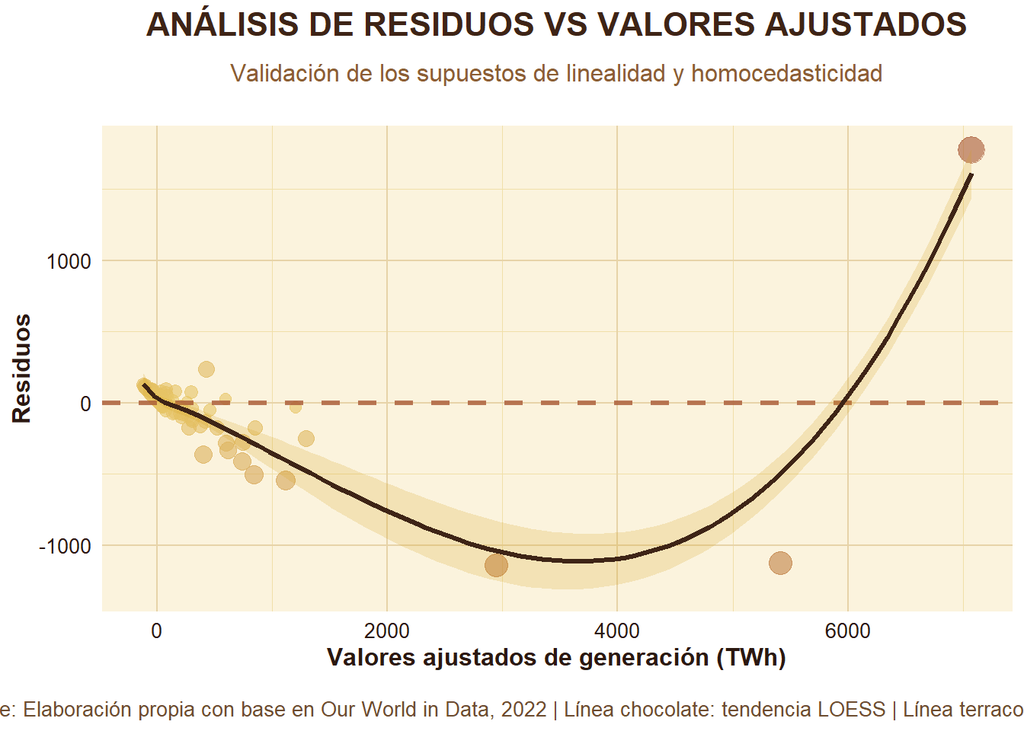

### 6.1.2 Normalidad

La normalidad de los residuos se evaluó mediante el gráfico Q-Q, comparando los cuantiles observados de los residuos con los esperados bajo una distribución normal. Cuando los puntos se mantienen próximos a la línea de referencia, se considera que los residuos presentan un comportamiento cercano a la normalidad.

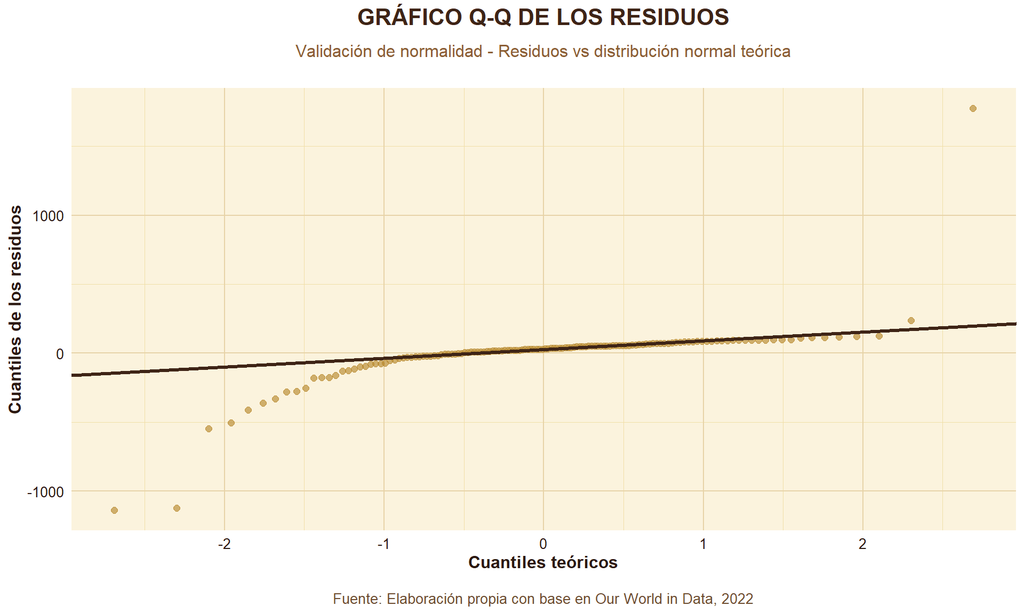

El gráfico muestra que los residuos se ajustan razonablemente a la línea de referencia en la parte central de la distribución. Sin embargo, hacia ambos extremos los puntos comienzan a separarse de manera considerable, con algunas observaciones especialmente alejadas de la línea. La desviación es particularmente evidente en la cola superior, donde aparece un residuo mucho mayor que el resto. Por lo tanto, el supuesto de normalidad no se cumple completamente, principalmente por la presencia de residuos extremos. Este comportamiento es coherente con la alta dispersión observada previamente en la generación de electricidad entre los países y deberá tenerse en cuenta al interpretar los resultados del modelo.

### 6.1.3 Homocedasticidad

El supuesto de homocedasticidad se evaluó mediante el gráfico Scale-Location, que permite observar si la dispersión de los residuos se mantiene aproximadamente constante a lo largo de los valores ajustados. Una tendencia relativamente horizontal indicaría una varianza estable, mientras que cambios marcados en la dispersión pueden evidenciar problemas de heterocedasticidad.

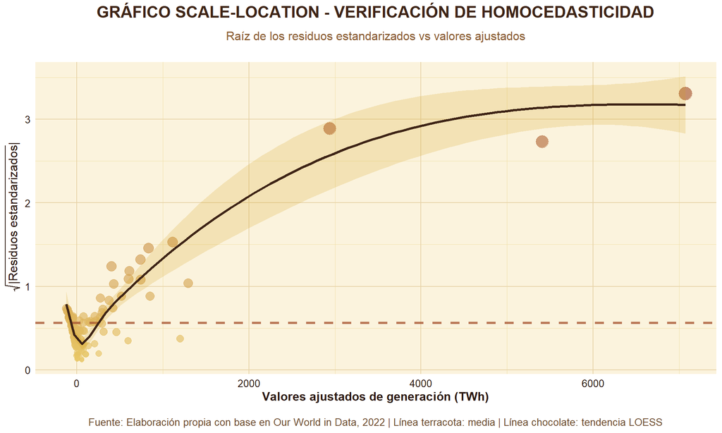

En el gráfico se observa que la dispersión de los residuos no permanece constante a medida que aumentan los valores ajustados de generación. La línea de tendencia presenta un crecimiento marcado y alcanza sus valores más altos en los países con mayores niveles de generación estimada. Además, algunas observaciones se encuentran considerablemente alejadas del grupo principal. Este comportamiento indica la presencia de heterocedasticidad, por lo que el supuesto de varianza constante de los errores no se cumple adecuadamente. Esto sugiere que la precisión del modelo no es uniforme para todos los países, especialmente en aquellos con niveles de generación más elevados.

### 6.1.4 VIF

La multicolinealidad entre las variables explicativas se evaluó mediante el Factor de Inflación de la Varianza (VIF). Debido a que el modelo incluye Continente, una variable categórica con varios niveles, se utilizó el GVIF ajustado para facilitar la comparación entre los términos del modelo. Valores elevados indicarían que algunas variables comparten demasiada información entre sí, lo que podría reducir la precisión de los coeficientes estimados.

Tabla 8: Análisis de multicolinealidad mediante VIF/GVIF

| Variable | GVIF | Df | GVIF ajustado | Diagnóstico |
| --- | --- | --- | --- | --- |
| PIB | 3.261 | 1 | 1.806 | ACEPTABLE |
| Poblacion | 3.230 | 1 | 1.797 | ACEPTABLE |
| Acceso | 2.498 | 1 | 1.580 | ACEPTABLE |
| Consumo | 1.481 | 1 | 1.217 | ACEPTABLE |
| Continente | 3.036 | 5 | 1.117 | ACEPTABLE |

Nota: Elaboración propia con base en Our World in Data, 2022. Para términos con varios grados de libertad se reporta el GVIF ajustado.

Los resultados muestran que todas las variables presentan valores de GVIF ajustado dentro de rangos aceptables, por lo que no se evidencian problemas importantes de multicolinealidad en el modelo. Los valores más altos corresponden al PIB (1,806) y la Población (1,797), aunque ambos se mantienen en niveles adecuados. Por su parte, Acceso presenta un valor de 1,580, Consumo de 1,217 y Continente de 1,117. En conjunto, estos resultados indican que, aunque existe cierta relación entre algunas de las variables explicativas, esta no alcanza niveles que representen un problema relevante para la estimación del modelo. Por lo tanto, el supuesto relacionado con la ausencia de multicolinealidad importante se considera satisfecho.

# 7 Conclusiones

El análisis realizado permitió estudiar la relación entre la generación total de electricidad y diferentes características socioeconómicas y energéticas de 140 países durante 2022. En conjunto, el modelo presentó un R² ajustado de 0,9192 y fue estadísticamente significativo (p < 0,0001), lo que indica que las variables incluidas explican una proporción importante de las diferencias observadas en la generación de electricidad entre los países analizados.

Sin embargo, al evaluar cada predictor de manera individual y manteniendo constantes las demás variables, únicamente el PIB total presentó una asociación estadísticamente significativa con la generación de electricidad (p < 0,0001). La población, el consumo de electricidad per cápita, el acceso a electricidad y el continente no mostraron evidencia suficiente de una asociación independiente al nivel de significancia del 5 %. Esto no implica que estas variables carezcan de relación con la generación, sino que dentro de la especificación utilizada su aporte adicional no resultó estadísticamente significativo.

Los diagnósticos también muestran limitaciones importantes. Los residuos presentan una curvatura marcada, desviaciones respecto a la normalidad y cambios en su dispersión a medida que aumentan los valores ajustados, por lo que los supuestos de linealidad, normalidad y homocedasticidad no se cumplen completamente. En contraste, el análisis mediante VIF/GVIF no evidenció problemas importantes de multicolinealidad entre las variables explicativas. Además, la presencia de países con niveles de generación considerablemente superiores al resto influye en el comportamiento del modelo.

Por lo tanto, el modelo permite responder parcialmente al objetivo de investigación: identifica al PIB como el factor que presenta la asociación estadística más clara con la generación total de electricidad dentro de las variables consideradas y muestra que, en conjunto, estas variables tienen una alta capacidad explicativa. No obstante, las dificultades encontradas en los supuestos impiden considerar la especificación lineal actual como una representación completamente adecuada de las relaciones presentes en los datos. Como extensión, sería conveniente evaluar transformaciones de las variables o especificaciones alternativas que permitan representar mejor las diferencias entre países y reducir la influencia de observaciones extremas.

Finalmente, los resultados deben interpretarse como asociaciones y no como relaciones causales, debido a que el análisis utiliza información observacional de los países para un único año.

# 8 Referencias Bibliograficas

Banco Mundial. (s. f.). Consumo de energía eléctrica (kWh per cápita). Datos del Banco Mundial. https://datos.bancomundial.org/indicador/EG.USE.ELEC.KH.PC?utm_source

Banco Mundial. (2022). Informe sobre el desarrollo mundial 2022: Finanzas al servicio de la recuperación equitativa. https://www.bancomundial.org/es/publication/wdr2022?utm_source

Banco Mundial. (s. f.). PIB (US$ a precios actuales). Datos del Banco Mundial. https://datos.bancomundial.org/indicador/NY.GDP.MKTP.CD?utm_source

El Economista. (2024, 12 de junio). El acceso a la electricidad en el mundo disminuyó en 2022 por primera vez en una década. https://www.eleconomista.com.mx/internacionales/El-acceso-a-la-electricidad-en-el-mundo-disminuyo-en-2022-por-primera-vez-en-una-decada-20240612-0038.html?utm_source.

International Energy Agency. (2022). World Energy Outlook 2022. IEA. https://www.iea.org/reports/world-energy-outlook-2022?utm_source

Our World in Data. (s. f.). Access to Energy. https://ourworldindata.org/energy-access?utm_source

Our World in Data. (s. f.). Electricity generation. https://ourworldindata.org/grapher/electricity-mix?source=total&metric=generation&frequency=annual

Our World in Data. (s. f.). Population & Demography Data Explorer. https://ourworldindata.org/explorers/population-and-demography?indicator=Population&Sex=Both+sexes&Age=Total&Projection+scenario=None&country=CHN~IND~USA~IDN~PAK~NGA~BRA~JPN

Our World in Data. (s. f.). World regions according to Our World in Data. https://ourworldindata.org/grapher/continents-according-to-our-world-in-data?utm_source

Ritchie, H., Rosado, P., & Roser, M. (2022). Energy. Our World in Data. https://ourworldindata.org/energy?utm_source

Semana. (2023). En el 2022 se incrementaron los proyectos de generación y de transmisión energética. https://www.semana.com/economia/empresas/minas-y-energia/articulo/en-el-2022-se-incrementaron-los-proyectos-de-generacion-y-de-transmision-energetica/202342/?utm_source